# Prosper Loan Data

## by Mahmoud Wasfy

## Investigation Overview

> The overall goals of this presentation is to show some insights about the Prosper Loan Data.

## Dataset Overview

> The Prosper Laon Data includes around 114,000 loans between year 2005 and 2014. In the coming slides we will investigate the interactions between features such as the Loan Amount, income ranges, loan status, Term of payment and Employment status for the borrower.

## (Visualization 1)

### How does the Borrower Income Range affect the Loan Original Amount? Does the Term of payment make any difference?

> > We conclude that as the Loan Amount increase with the increase of the borrower income range and also with the increase of number of months to pay back the loan.

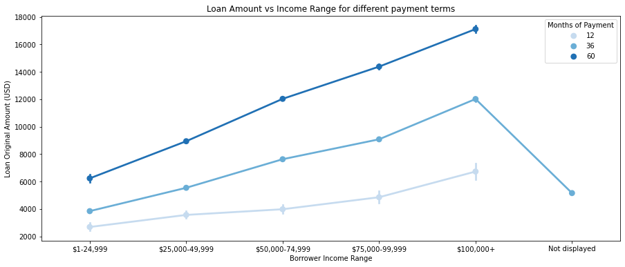

```python
plt.figure(figsize= (15,6))


sb.pointplot(data = df, x = 'IncomeRange', y = 'LoanOriginalAmount', hue = 'Term',
           palette = 'Blues' )

plt.xlabel('Borrower Income Range')
plt.ylabel('Loan Original Amount (USD)')
plt.title('Loan Amount vs Income Range for different payment terms')
plt.legend(title='Months of Payment');
```

## (Visualization 2)

### What is the avarage loan amount for different borrowers Employement Status? Does the trend changes with the change of the loan status?

#### We Conclude from the following plot that the completed loans had lower value than the current ones for all employment status of the borrower. It is also worth mentioning that the past due loans (61 - 120) are the highest for the Self Employed & Part timers while it is the lowest for the Retired borrowers.

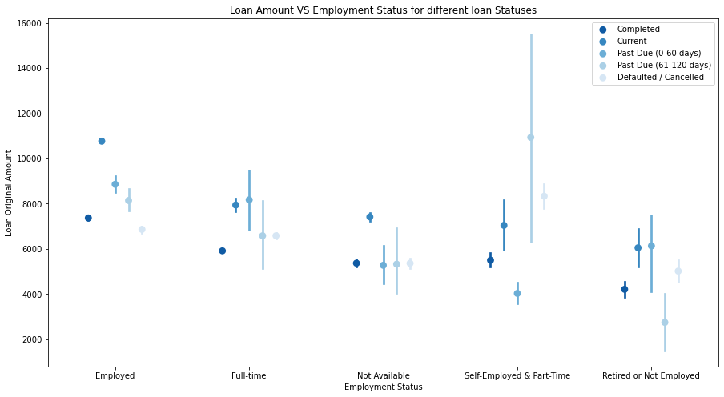

```python
plt.figure(figsize= (15,8))


sb.pointplot(data = df, x = 'EmploymentStatus', y = 'LoanOriginalAmount', hue = 'LoanStatus',
           palette = 'Blues_r', linestyles='' , dodge = 0.4  )

plt.xlabel('Employment Status')
plt.ylabel('Loan Original Amount')
plt.title('Loan Amount VS Employment Status for different loan Statuses')
plt.legend();
```

## (Visualization 3)

### What is the mean value of the loan for different Income Range? is it affected by the fact that the borrower is a home-owner?

#### The following plot shows that the mean value of the loan increases with the increase of the income range. It is also noticable that home owners have a higher loans on avarage for all different income ranges.

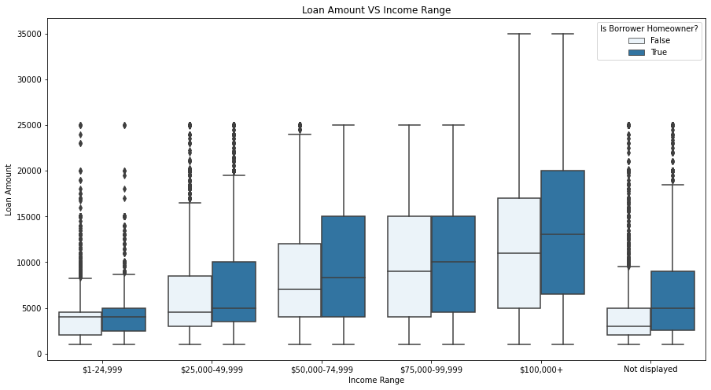

```python
plt.figure(figsize=(15,8))
base_color = sb.color_palette()[0]
sb.boxplot(x='IncomeRange', y = 'LoanOriginalAmount', data=df, order=income_range_order, color=base_color, hue='IsBorrowerHomeowner');

plt.xlabel('Income Range')
plt.ylabel('Loan Amount')
plt.title('Loan Amount VS Income Range')

plt.legend(title= 'Is Borrower Homeowner?');
```